# Prediction assignment

A.J.Nicholson

Tuesday, April 21, 2015

### Introduction

This analysis’ aim is to predict the manner in which participants performed barbell lifts.

The data use in the analysis found at http://groupware.les.inf.puc-rio.br/har. It consists of data from accelerometers on the belt, forearm, arm, and dumbbell of 6 participants. They were asked to perform barbell lifts correctly and incorrectly in 5 different ways.

```r
#Loading in training data
TrainURL<-"http://d396qusza40orc.cloudfront.net/predmachlearn/pml-training.csv"
download.file(TrainURL,"train.csv")
train<-read.csv("train.csv", header=TRUE)

#loading in testing data
TestURL<-"http://d396qusza40orc.cloudfront.net/predmachlearn/pml-testing.csv"
download.file(TestURL,"test.csv")
test<-read.csv("test.csv", header=TRUE)
```

The train dataset was split into two so that out of sample accuracy could be estimated.

```r
#creating a testing set
library(caret)
inTrain <- createDataPartition(y=train$classe,
                               p=0.75, list=FALSE)
testing <- train[-inTrain,]
train<-train[inTrain,]
```

### Cleaning Data/ Reducing Variables

The dataset consists of 160 variables, this is too many to realistically use in a model as independent variables. So initial stage of this analysis is to reduce these down to a more manageable number

The first step in doing so is to ignore the 3 time stamp variables as well as new window and num window. I am also excluding the user name variable, as training a model to specific users limits future uses.

Next it is clear that the data can mostly be divided into 4 groups, corresponding to the 4 separate sensors; forearm, arm, dumbbell and belt. As such I produced 4 separate dataset to make further decomposition of variables easier; each of these dataset also contained copies of the outcome (classe).

```r
#Example of spliting data into sensor groups (forearm)
forearm<-grep("forearm",names(train))
trainFA<-train[,forearm];trainFA$classe<-train$classe
```

```r
#Example of variables with large numbers of NA values (arm data)
SumA<-(data.frame(summary(trainA)))[grep("NA's",summary(trainA)),]
NAA<-as.vector(SumA$Var2)
NAA
```

[1] “var_accel_arm” " avg_roll_arm" “stddev_roll_arm”  
[4] " var_roll_arm" “avg_pitch_arm” “stddev_pitch_arm”  
[7] “var_pitch_arm” " avg_yaw_arm" “stddev_yaw_arm”  
[10] " var_yaw_arm" " max_roll_arm" “max_picth_arm”  
[13] " max_yaw_arm" " min_roll_arm" “min_pitch_arm”  
[16] " min_yaw_arm" “amplitude_roll_arm” “amplitude_pitch_arm” [19] “amplitude_yaw_arm”

As you can see these are all in some way a summary statistic; e.g. variance, average. In addition to these fields there are also columns for kurtosis and skewness, which instead of NA are mainly populated with missing values. As all of these variables are clear derivatives of the other variables, so will be excluded.

```r
#removing variables that had large numbers of NA's (example on Arm data)
NAA<-as.vector(SumA$Var2);NAA<-paste(NAA,collapse="|");NAA<-gsub(" ","",NAA,fixed=TRUE)
NAA<-grep(NAA,names(trainA));trainA<-trainA[,-NAA]

#removing kurtosis and skewness fields (example on arm data)
KandS<-grep("kurtosis|skewness",names(trainA));trainA<-trainA[,-KandS]
```

The next stage is the production of feature plots. So that these are easily visible I only included some of the variables in each plot.

To look at meaningful relationships I group the variable by type of reading; i.e all magnetometer reading for a particular sensor (magnet_[sensor]*[x|Y|z]). I also produced plots in which the variables where grouped by the axis they described; e.g the x- axis for the arm data is described by the variables rollarm, gyros*arm_x, magnet_arm_x and accel_arm_x.

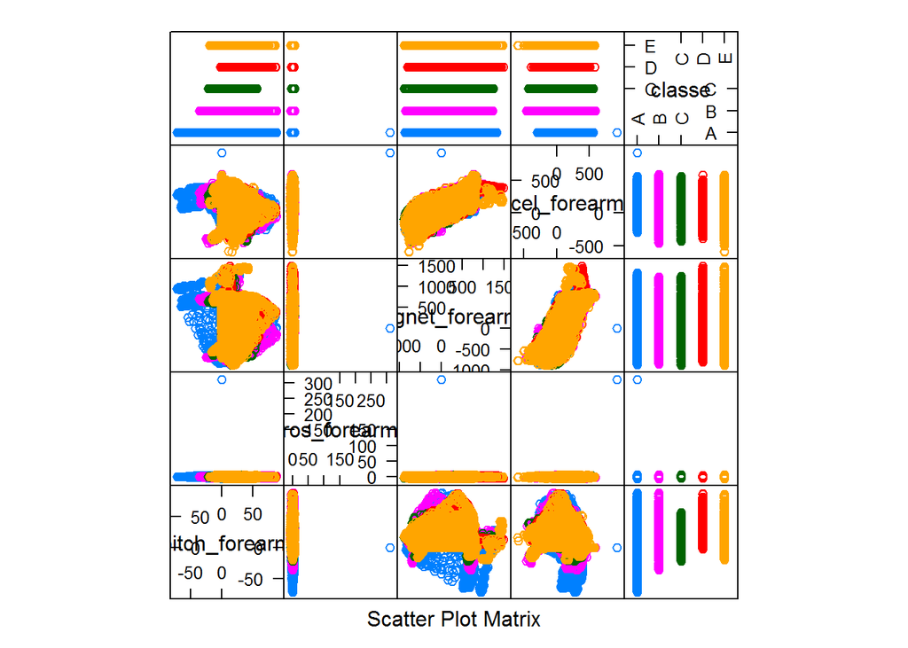

```r
library(caret);library(ggplot2)
#Y axis measures forearm
featurePlot(x=trainFA[,c("pitch_forearm","gyros_forearm_y","magnet_forearm_y","accel_forearm_y","classe")],
            y = trainFA$classe,
            plot="pairs")
```

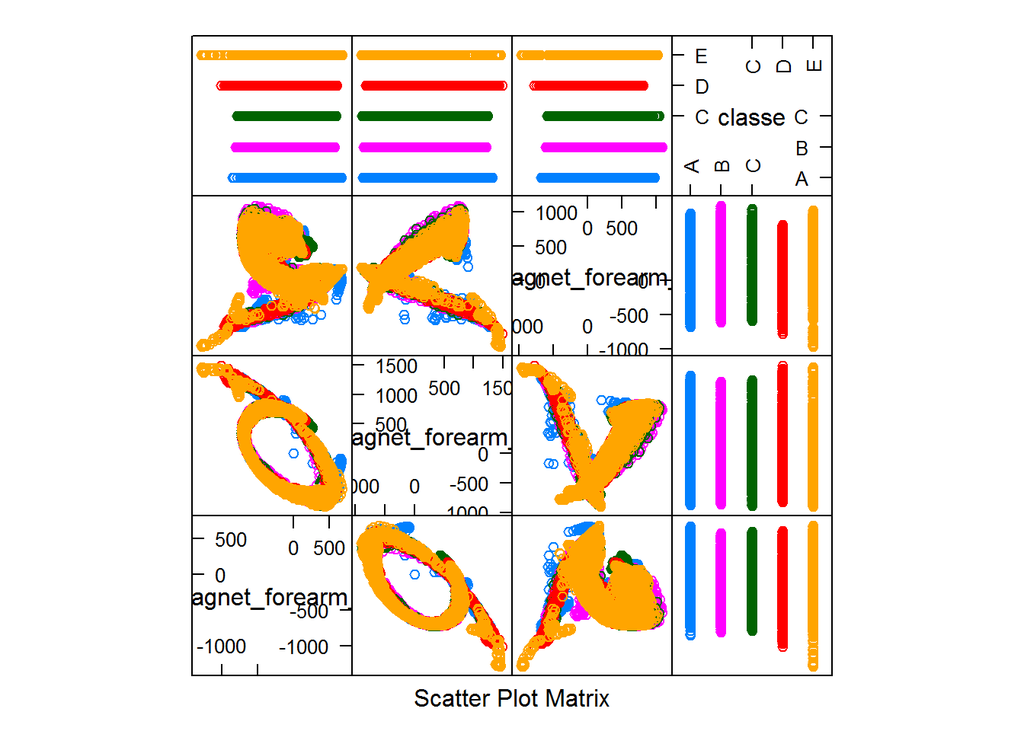

```r
#magnetrometer measures forearm
featurePlot(x=trainFA[,c("magnet_forearm_x","magnet_forearm_y","magnet_forearm_z","classe")],
            y = trainFA$classe,
            plot="pairs")
```

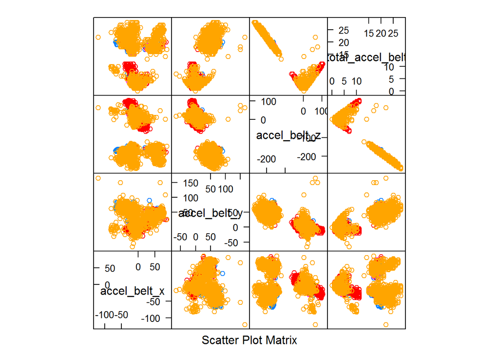

```r
#accelatrometer measure belt
featurePlot(x=trainB[,c("accel_belt_x","accel_belt_y","accel_belt_z", "total_accel_belt")],
            y = trainB$classe,
            plot="pairs")
```

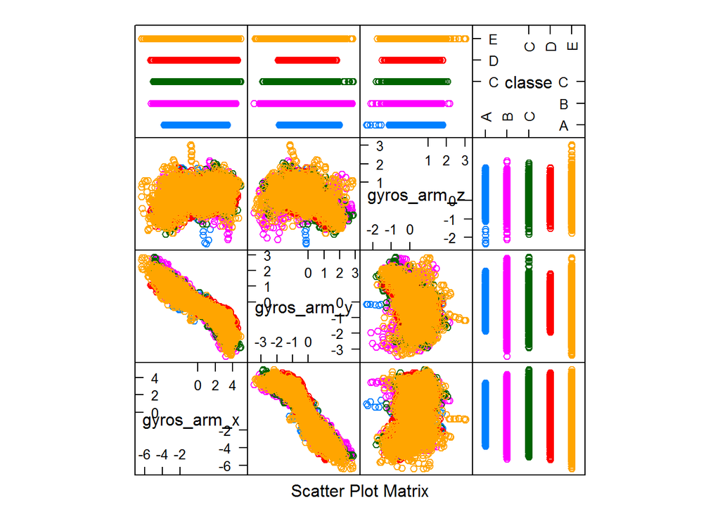

```r
#gyro's arm
featurePlot(x=trainA[,c("gyros_arm_x","gyros_arm_y","gyros_arm_z","classe")],
            y = trainA$classe,
            plot="pairs")
```

The first thing to note from the feature plots is that no single variable or combination of two variable produced a clear separation of classe. This suggested a successful model would have to include multiple variables.

It is also clear that a lot of the variables are interrelated, e.g. magnet_forearm_y and accel_forearm_y: Many of which are complex relationships, e.g. magnetrometer data . This suggest that some kind of interaction needs to be considered when constructing the prediction model.

Unsurprisingly the total_accel variable shows a strong relationship with the other accel variable in particular the accel in the z direction. I decided to remove this variable from consideration as it is a clear product of other variables, which will be used in the model instead.

The other thing that is evident from the feature plots is that the gyro reading for the forearm and dumbbell, in all axes, are almost exclusively 0’s. As such this isn’t a useful predictors so will be removed.

### Model Construction

Now that I have my set of variable the next step is to explore different possible models.

All the model I will construct for this analysis will use the random forest method, as it works well on non-parametric data with factor outcomes and produces high accuracy. I will use this within the train() , as appose to randomforest(),function as by default it cross validates, by bootstrapping through 25 reps.

I will compare 5 different models with different treatment of variables:

1. Model One: Simple use of all variables

```r
#getting variable names as a character string
Variables<-as.vector(names(c(trainA[,-13],trainB[,-13],trainD[,-10],trainFA[,-10])))
Variables<-paste(Variables,collapse="|");Variables<-gsub(" ","",Variables,fixed=TRUE)

#selecting those varibles from the train data set, while excluding eronious matches
not<-grep("avg|max|kurtosis|amplitude|stddev|skewness|var|min",names(train))
Variables<-grep(Variables,names(train[,-not]),value=TRUE)

#running the model
set.seed(456)
model1<-train(train$classe ~ .,method="rf",data=train[,Variables])
```

2. Model Two: All variable processed into Principal Components

```r
#producing principal components
PCA<-preProcess(train[,Variables],method="pca")
trainPC <- predict(PCA,train[,Variables])

#running the model
set.seed(456)
model2 <- train(train$classe ~ .,method="rf",data=trainPC)
```

3. Model Three: Pre-processing variable from each sensor into principal components

```r
#example of producing principal components from each sensor (dumbbell)
D<-as.vector(names(trainD[,-10]));D<-paste(D,collapse="|")
D<-gsub(" ","",D,fixed=TRUE);D<-grep(D,names(train[,-not]),value=TRUE)
PCAd<-preProcess(train[,D],method="pca");PCAD<-predict(PCAd,train[,D])

#putting all principal components into a single dataframe, with unique names for each variable
PCA1<-cbind(PCAA,PCAB,PCAD,PCAFa)
names(PCA1)<-c("a1","a2","a3","a4","a5","a6","a7","a8","b1","b2","b3","b4","b5","b6","d1","d2","d3","d4","d5","d6","fa1","fa2","fa3","fa4","fa5","fa6","fa7")

#running the model
set.seed(456)
model3 <- train(train$classe ~ .,method="rf",data=PCA1)
```

4. Model Four: Principal components of each type of reading for each sensor, this excludes the pitch, yaw and roll variables.

```r
#example of principal component for each type of measurement (accelerometer forearm)
accFA<-grep("accel_forearm_x|accel_forearm_y|accel_forearm_z",names(train[,-not]),value=TRUE)
afa<-preProcess(train[,accFA],method="pca");aFa<-predict(afa,train[,accFA])

#creating one dataframe with all PCA's with unique names
PCA2<-cbind(aFa,aD,aB,aA,mFa,mD,mB,mA,gB,gA)
names(PCA2)<-c("afa1","afa2","afa3","ad1","ad2","ad3","ab1","ab2","ab3","aa1","aa2","aa3","mfa1","mfa2","mfa3","md1","md2","md3","mb1","mb2","mb3","ma1","ma2","gb1","gb2","gb3","ga1","ga2")

#running model
set.seed(456)
model4 <- train(train$classe ~ .,method="rf",data=PCA2)
```

5. Model Five: Principal components of each axis for each sensor.

```r
#example of principal component analysis for each axis (dumbbell z axis)
ZD<-grep("yaw_dumbbell|magnet_dumbbell_z|accel_dumbbell_z",names(train[,-not]),value=TRUE)
zd<-preProcess(train[,ZD],method="pca");zD<-predict(zd,train[,ZD])

#putting all principal components in a single data frame with unique names for each variable
PCA3<-cbind(xA,xB,xD,xFa,yA,yB,yD,yFa,zA,zB,zD,zFa)
names(PCA3)<-c("xa1","xa2","xa3","xb1","xb2","xb3","xd1","xd2","xd3","xfa1","xfa2","xfa3",
               "ya1","ya2","ya3","ya4","yb1","yb2","yb3","yb4","yd1","yd2","yd3","yfa1","yfa2","yfa3",
               "za1","za2","za3","zb1","zb2","zb3","zb4","zd1","zd2","zfa1","zfa2","zfa3")

#running the model
set.seed(456)
model5<-train(train$classe ~ .,method="rf",data=PCA3)
```

### Model Evaluation

In order to evaluate the models each is applied to the testing data set. This will give an out of sample error estimation.

```r
#model 1
test1 <- predict(model1,newdata=testing)
confusion1<-confusionMatrix(testing$classe,test1)
#model 2
test2 <- predict(PCA,testing[,Variables]);test2<-predict(model2,test2)
confusion2<-confusionMatrix(testing$classe,test2)
#model 3
test3<-predict(model3,PCA1)
confusion3<-confusionMatrix(testing$classe,test3)
#model 4
test4<-predict(model4,PCA2)
confusion4<-confusionMatrix(testing$classe,test4)
#model 5
test5<-predict(model5,PCA3)
confusion5<-confusionMatrix(testing$classe,test5)
```

In-sample accuracy is extractible from the model$results. This can be compared with out of sample accuracy extracted from confusion_matrix$overall.

estimation of in and out of sample error

[output not shown]

From this table there is little difference in the models in terms of accuracy, with model 1 coming out on top with an in sample accuracy of 0.9888671 and an out of sample accuracy of 0.9920473. Model 2 and model 4 show the lowest accuracy at around 96%.

A further way of comparing the variables is by comparing their predictions of the 20 variables in the test dataset. (n.b. the actual classe is not given in the test data set).

predicted values for 20 test cases for each model

| test1 | test2 | test3 | test4 | test5 |
| --- | --- | --- | --- | --- |
| B | B | B | B | B |
| A | A | A | A | A |
| B | A | B | B | B |
| A | A | A | A | A |
| A | A | A | A | A |
| E | E | E | C | E |
| D | D | D | D | D |
| B | B | B | B | B |
| A | A | A | A | A |
| A | A | A | A | A |
| B | B | B | B | B |
| C | C | C | C | C |
| B | B | B | B | B |
| A | A | A | A | A |
| E | E | E | E | E |
| E | E | E | E | E |
| A | A | A | A | A |
| B | B | B | B | B |
| B | B | B | B | B |
| B | B | B | B | B |

In general the predictions are similar across all models. Test 2 and test 4 both predict variables differently, in the 3 and 6 rows respectively.

### Model selection

All models performed relatively well with high accuracy both in and out of sample. When picking a preferred model both model 2 and 4 should be discounted because they performed slightly worse; although it should be noted that test 2 only used 7 variables in the model which is significantly less than the others.

Choosing between the remaining three models, model one would be my preferred choice. It scored marginally better on the accuracy measures. However the reason it is really preferential is that it uses straight variables not principal components of variables. This makes it a more interpretable model.